# Stats418-Machine Learning #3

Jason

May 23, 2017

```r
knitr::opts_chunk$set(echo = TRUE)
```

# Overview:

The purpose is to use an UCI data set as an exploration into machine learning packages with the goal of predicting if someone earns more than $50K/year.

Based on validation data set:

[output not shown]

# Scope of machine learning methods:

1. Logistic Regression (R package glmnet)
2. Logistic Regression with Lasso
3. Logistic Regression (H20)
4. Random Forest
5. Gradient Boosting Machines

# Data:

This machine learning homework is based on the UCI data set Census and Income located here: https://archive.ics.uci.edu/ml/datasets/Census+Income. It is US 1994 Census data setup with each row of data as an individual. The goal of the data set is to predict if an individual makes more than $50k/year or less. There are a total of 48k observations and 14 attributes.

# Setup Notes & Issues:

1. A quick look at the goal and about 2/3 of the data set population make less than $50K/year
2. Online, the author has already split the data set to train and test. The train file didn’t meet the homework requirements for the amount of positive results alone. I therefore merged the two together and then split it based on my own random number (set.seed(123)).
3. Original authors eliminated all rows with Nulls reducing the observations from 48k to 45k (7%). As the goal is to explore several machine learning packages and compare AUC and as it still is a significant number, I’m going to eliminate null value rows. A future project could look into predicting and filling in the gaps.
4. The variable education which describes the most education tier the individual accomplished is very similar to the education-num which is the numerical equivalent.
5. The data is not ready for entering into the various models as its not binary, or factors and needs to be adjusted to machine learning packages
6. I have transformed attributes into a binary and factors
7. I have added categories which summarizes several underlining variables

```r
set.seed(123)



library(data.table)
library(dplyr)
library(xgboost)
library(h2o)
library(glmnet)
library(ROCR)

#H20 setup
h2o.no_progress() # Don't show progress bars in RMarkdown output


data1 <- fread('https://archive.ics.uci.edu/ml/machine-learning-databases/adult/adult.data')
head(data1,2L)
```

```
##    V1               V2    V3        V4 V5                 V6
## 1: 39        State-gov 77516 Bachelors 13      Never-married
## 2: 50 Self-emp-not-inc 83311 Bachelors 13 Married-civ-spouse
##                 V7            V8    V9  V10  V11 V12 V13           V14
## 1:    Adm-clerical Not-in-family White Male 2174   0  40 United-States
## 2: Exec-managerial       Husband White Male    0   0  13 United-States
##      V15
## 1: <=50K
## 2: <=50K
```

```r
data2 <- fread('https://archive.ics.uci.edu/ml/machine-learning-databases/adult/adult.test',autostart = 2)
head(data2,2L)
```

```
##    V1      V2     V3      V4 V5                 V6                V7
## 1: 25 Private 226802    11th  7      Never-married Machine-op-inspct
## 2: 38 Private  89814 HS-grad  9 Married-civ-spouse   Farming-fishing
##           V8    V9  V10 V11 V12 V13           V14    V15
## 1: Own-child Black Male   0   0  40 United-States <=50K.
## 2:   Husband White Male   0   0  50 United-States <=50K.
```

```r
dim(data1)
```

```
## [1] 32561    15
```

```r
#data1: Observations: 32,561   Columns: 15
dim(data2)
```

```
## [1] 16281    15
```

```r
data1<-as.data.table(data1)
data2<-as.data.table(data2)
#data2: Observations: 16,281   Columns: 15

colnames(data1) <- c("age","workclass","fnlwgt","education","educationnum","maritalstatus","occupation","relationship","race","sex","capitalgain","capitalloss","hoursperweek","nativecountry","class")
colnames(data2) <- c("age","workclass","fnlwgt","education","educationnum","maritalstatus","occupation","relationship","race","sex","capitalgain","capitalloss","hoursperweek","nativecountry","class")

#GLMNET doesnt like '-' in names!!!

data3<-rbind(data1,data2)

#data2: Observations: 48,842   Columns: 15
#check row counts
NROW(data3)-(NROW(data1)+NROW(data2))
```

```
## [1] 0
```

```r
# equal 0
remove(data1)
remove(data2)

#Delete "?"" values

# Observations reduced from 48,842 to 45,222 or 3,620 or 7.4%
data4 = data3[data3$age !='?' & data3$workclass !='?' & data3$fnlwgt !='?' & data3$education != '?' & data3$educationnum != '?' & data3$maritalstatus != '?' & data3$occupation != '?' & data3$relationship != '?' & data3$race != '?' & data3$sex != '?' & data3$capitalgain != '?' & data3$capitalloss != '?' & data3$hoursperweek != '?' & data3$nativecountry != '?'& data3$class != '?']
```

Additional categorical variables were created based on the data.

- These were the following groups
- Bachelors level (ba) which if bachelors or above (Masters and Doctorate) was in the education variable it would receive a 1. The input ‘some college’ receive a 0 rather a 1
- Not a High School graduate (nohs) mentioned in the education variable
- English as a primary language estimate based on native country (PrimEng). If native country is from a primary English spoken country than they would receive a 1 and all other would receive a 0
- Age grouping (agegrp) based on the age variable
- Native to the United States (native) based on the native-country variable
- Delete the class variable as I replaced it with binary goal variable

```r
# If data$goal = 1 then you make more than $50k and if 0 then you do not
# If data$native = 1 then you are native to the United States and 0 you are not

data4$goal <- as.factor(ifelse(data4$class == '>50K',1,
                        (ifelse(data4$class == '>50K.',1,0))))

data4$nativecountry <- as.factor(data4$nativecountry)

data4$native <- as.factor(ifelse(data4$nativecountry == 'United-States',1,0))
#Age groups buckets
#I assume 65 and older are likely retired and lower earners
data4$agegrp <- as.factor (ifelse (data4$age <21,'<21',
                          (ifelse(data4$age >=21 & data4$age<=30,'21-30',
                          (ifelse(data4$age>=31 & data4$age<=40, '31-40',
                          (ifelse(data4$age>=41 & data4$age<=50, '41-50',
                          (ifelse(data4$age>=51 & data4$age<=64, '51-64',
                          (ifelse(data4$age>64, '65+', NA))))))))))))

#Assuming if english language based on native country.  This actually just seems like my US native bucket and I might eject this
data4$PrimEng <- as.factor (ifelse (data4$nativecountry =='United-States',1,
                          (ifelse(data4$nativecountry == 'England',1,
                          (ifelse(data4$nativecountry =='Canada', 1,
                          (ifelse(data4$nativecountry =='Scotland', 1,
                          (ifelse(data4$nativecountry =='Ireland', 1,
                      (ifelse(data4$nativecountry=='Outlying-US(Guam-USVI-etc)',1,0))))))))))))

#Turn the rest into factors
  data4$workclass<- as.factor(data4$workclass)
  data4$education<- as.factor(data4$education)
  data4$maritalstatus<- as.factor(data4$maritalstatus)
  data4$occupation <- as.factor(data4$occupation)
  data4$relationship <- as.factor(data4$relationship)
  data4$race <- as.factor(data4$race)
  data4$sex <- as.factor(data4$sex)

#Group at least BA

data4$ba <- as.factor (ifelse (data4$education =='Bachelors',1,
                        (ifelse(data4$education == 'Doctorate',1,
                        (ifelse(data4$education =='Masters', 1,0))))))
#Group non-HS grads

data4$nohs <- as.factor (ifelse (data4$ba ==1,0,
                        (ifelse(data4$education == '10th',1,
                        (ifelse(data4$education == '11th',1,
                        (ifelse(data4$education == '12th',1,
                        (ifelse(data4$education == '1st-4th',1,
                        (ifelse(data4$education == '5th-6th',1,
                        (ifelse(data4$education == '7th-8th',1,
                        (ifelse(data4$education == '9th',1,
                        (ifelse(data4$education == 'Preschool',1,0))))))))))))))))))
# Variable class as I made binary goal variable
data4 <- data4[,class:=NULL]
```

# Preparing sets:

The first part is to split the data into train, validate and test groups based on 70% train, 15% validate and 15% test.

```r
d<-data4
N <- nrow(d)
idx <- sample(1:N, 0.7*N)
d_train <- d[idx,]
d_valtest <- d[-idx,]
id_valtest <- sample(1:nrow(d_valtest), 0.5*nrow(d_valtest))
d_val <- d_valtest[id_valtest,]
d_test <- d_valtest[-id_valtest,]

X <- Matrix::sparse.model.matrix(goal ~ . - 1, data = d)
X_train <- X[idx,]
X_valtest <- X[-idx,]
X_val <- X_valtest[id_valtest,]
X_test <- X_valtest[-id_valtest,]
```

# Logistic Regression with R package glmnet

```r
LRmd <- glmnet( X_train, d_train$goal, family = "binomial", lambda = 0)
phat <- predict(LRmd, newx = X_val, type = "response")

rocr_pred <- prediction(phat, d_val$goal)
performance(rocr_pred, "auc")@y.values[[1]]
```

```
## [1] 0.9068846
```

```r
#First model and very strong AUC without any model and feature tuning
```

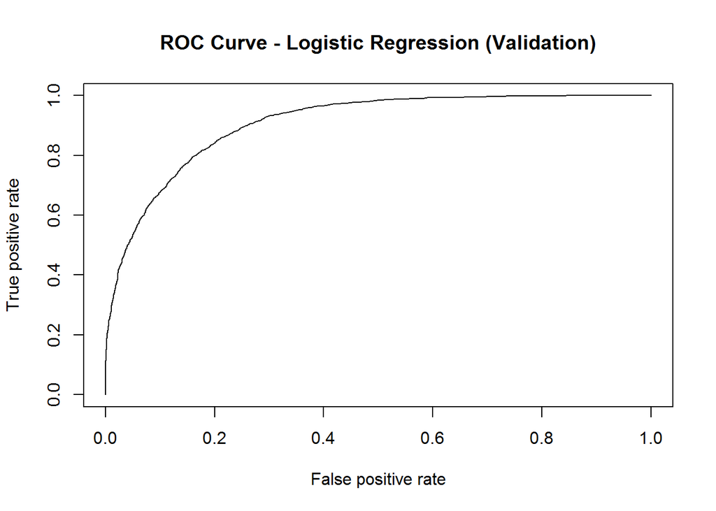

Can the AUC improve with some regularization?

```r
#Get lambda
LRmd2 <- cv.glmnet( X_train, d_train$goal, family = "binomial", type.measure="auc")
lambda <- LRmd2$lambda.min

print(lambda)
```

```
## [1] 0.0009716012
```

```r
#lambda seems pretty close to 0
```

```r
time1<- system.time({phatlrmd2 <- predict(LRmd2, newx = X_val, type = "response")})
print(time1)
```

```
##    user  system elapsed
##    0.01    0.00    0.02
```

```r
rocr_predlrmd2 <- prediction(phatlrmd2, d_val$goal)
performance(rocr_predlrmd2, "auc")@y.values[[1]]
```

```
## [1] 0.9048851
```

Now put lambda into the equation and calculate AUC

```r
#put lambda min into formula
LRmd3 <- glmnet(X_train, d_train$goal, family = "binomial", lambda=lambda)
phatlrmd3 <- predict(LRmd3, newx = X_val, type = "response")

rocr_predlrmd3 <- prediction(phatlrmd3, d_val$goal)
performance(rocr_predlrmd3, "auc")@y.values[[1]]
```

```
## [1] 0.9065015
```

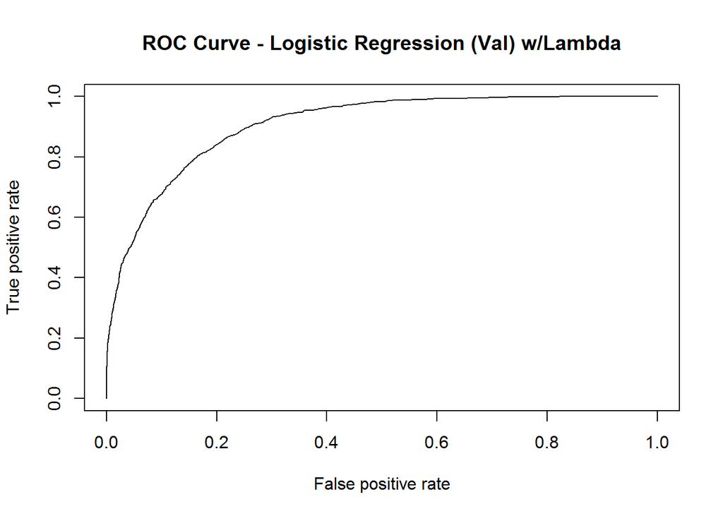

#Using H20 with logistic regression

```r
h2o.init(nthreads=-1)
```

```
##  Connection successful!
##
## R is connected to the H2O cluster:
##     H2O cluster uptime:         23 minutes 5 seconds
##     H2O cluster version:        3.10.3.6
##     H2O cluster version age:    3 months and 7 days
##     H2O cluster name:           H2O_started_from_R_YiJ_tyr936
##     H2O cluster total nodes:    1
##     H2O cluster total memory:   3.35 GB
##     H2O cluster total cores:    4
##     H2O cluster allowed cores:  4
##     H2O cluster healthy:        TRUE
##     H2O Connection ip:          localhost
##     H2O Connection port:        54321
##     H2O Connection proxy:       NA
##     R Version:                  R version 3.3.3 (2017-03-06)
```

[output not shown]

```r
#with regularization
LRmd5 <- h2o.glm(x = Xnames, y = "goal", training_frame = htrain,
                family = "binomial", alpha = 1, lambda_search=TRUE)
h2o.auc(h2o.performance(LRmd5, hval))
```

```
## [1] 0.9117622
```

Try it with prior minimum Lambda

```r
#with lambda from prior lambda minimum
LRmd6 <- h2o.glm(x = Xnames, y = "goal", training_frame = htrain,
                family = "binomial", alpha = 1, lambda=lambda)
h2o.auc(h2o.performance(LRmd6, hval))
```

```
## [1] 0.9104225
```